# The Anchor and the Orbit

What actually moves Enchanted Lorcana prices: error correction, listing microstructure, and market segments

Author

Lorecaster — exploration/softmax_report

Published

July 7, 2026

```r
library(DBI);   library(duckdb)
library(dplyr); library(tidyr);   library(purrr)
library(mgcv);  library(survival)
library(broom); library(ggplot2); library(ggrepel)
library(knitr); library(cluster)

tok <- list(
  surface = "#fcfcfb", ink = "#0b0b0b", ink2 = "#52514e", muted = "#898781",
  grid = "#e1e0d9", baseline = "#c3c2b7",
  up = "#2a78d6", down = "#e34948", flat = "#898781",
  seq5 = c("#86b6ef", "#5598e7", "#2a78d6", "#1c5cab", "#0d366b"),
  cat4 = c("#2a78d6", "#1baf7a", "#eda100", "#4a3aa7")  # slots 1,2,3,5
)
theme_lorecaster <- function(base_size = 12) {
  theme_minimal(base_size = base_size) +
    theme(
      plot.background  = element_rect(fill = tok$surface, colour = NA),
      panel.background = element_rect(fill = tok$surface, colour = NA),
      panel.grid.major = element_line(colour = tok$grid, linewidth = 0.3),
      panel.grid.minor = element_blank(),
      axis.text  = element_text(colour = tok$ink2),
      axis.title = element_text(colour = tok$ink2),
      plot.title = element_text(colour = tok$ink, face = "bold"),
      plot.subtitle = element_text(colour = tok$ink2),
      plot.caption  = element_text(colour = tok$muted, size = 9),
      strip.text  = element_text(colour = tok$ink2, face = "bold"),
      legend.text = element_text(colour = tok$ink2),
      legend.title = element_text(colour = tok$ink2),
      legend.position = "top"
    )
}
set.seed(1789)
```

## 0. Where the last report left off

The companion softmax analysis found that the strongest predictor of a card’s next week was its *own recent past*: a +25% two-week run-up multiplied the odds of a retrace. It read as mean reversion — but a softmax on one price feed can’t say **why**.

This report brings in the data that can: `justtcg_prices` holds 430 days of daily **TCGplayer market prices** for the same 284 Enchanted cards, and the listing scrape itself contains 28,725 individual listing lifecycles nobody had touched. Four questions, four model families:

1. **Which market leads?** — panel Granger regressions & an error-correction model (the project plan assumed eBay is the leading indicator; we test it).
2. **Is “momentum” real, or a shadow of something else?** — nested GLMs and a GAM with card random effects.
3. **What does a listing’s *price* do to its *lifespan*?** — Cox proportional hazards on 16,928 listing lifecycles.
4. **Is this one market or several?** — k-means segmentation of card-level behavior, then testing whether the correction mechanism differs by segment.

```r
con <- dbConnect(duckdb::duckdb())
invisible(dbExecute(con, "INSTALL motherduck; LOAD motherduck;"))
invisible(dbExecute(con, "ATTACH 'md:my_db' AS my_db;"))
invisible(dbExecute(con, "USE my_db;"))

daily_all <- dbGetQuery(con, "
  SELECT id, date_pulled, count(*) AS n_active, median(price_val) AS median_price
  FROM lorcana_active_listings GROUP BY id, date_pulled")
daily_split <- dbGetQuery(con, "
  SELECT id, date_pulled, is_graded, count(*) AS n_active,
         median(price_val) AS median_price
  FROM lorcana_active_listings GROUP BY id, date_pulled, is_graded")
tcg <- dbGetQuery(con, "
  SELECT tcgplayer_id, pull_date, market_price
  FROM justtcg_prices WHERE pull_date >= DATE '2026-02-23'")
lifecycle <- dbGetQuery(con, "
  SELECT id, item_id, min(date_pulled) AS first_seen, max(date_pulled) AS last_seen,
         arg_min(price_val, date_pulled)   AS entry_price,
         arg_min(is_graded, date_pulled)   AS is_graded,
         arg_min(listing_type, date_pulled) AS listing_type
  FROM lorcana_active_listings GROUP BY id, item_id")
dbDisconnect(con, shutdown = TRUE)

meta <- readRDS("../../data/enchanteds/enchanted_list_05_07.rds") |>
  transmute(id, tcgplayer_id = as.character(tcgplayer_id), name, version, set_name)

px <- daily_all |>
  inner_join(meta |> select(id, tcgplayer_id), by = "id") |>
  transmute(tcgplayer_id, date = as.Date(date_pulled),
            eb_price = median_price, n_active) |>
  inner_join(tcg |> transmute(tcgplayer_id = as.character(tcgplayer_id),
                              date = as.Date(pull_date), tcg_price = market_price),
             by = c("tcgplayer_id", "date")) |>
  filter(n_active >= 5, eb_price > 0, tcg_price > 0) |>
  mutate(gap = log(eb_price / tcg_price)) |>
  group_by(tcgplayer_id) |>
  mutate(gap_dev = gap - mean(gap)) |>   # deviation from the card's own premium
  arrange(date, .by_group = TRUE) |> ungroup()
```

## 1. Two markets, one anchor

eBay listing medians sit far above TCGplayer market prices — the median card asks a **100% premium** (asking prices vs. transaction-anchored market prices, plus the graded mix). The question is who *moves* first when prices change.

```r
wk <- px |>
  group_by(tcgplayer_id) |> arrange(date, .by_group = TRUE) |>
  mutate(
    d_eb_7   = log(eb_price)  - log(eb_price[match(date - 7, date)]),
    d_tcg_7  = log(tcg_price) - log(tcg_price[match(date - 7, date)]),
    d_eb_prev7  = d_eb_7[match(date - 7, date)],
    d_tcg_prev7 = d_tcg_7[match(date - 7, date)],
    gap_lag8    = gap_dev[match(date - 8, date)],
    d_eb_indep  = log(eb_price[match(date - 8, date)]) -
                  log(eb_price[match(date - 15, date)])
  ) |> ungroup()

anchor_wd <- as.POSIXlt(max(px$date))$wday
wk7 <- wk |> filter(as.POSIXlt(date)$wday == anchor_wd)

gr <- wk7 |> filter(complete.cases(d_eb_7, d_tcg_7, d_eb_prev7, d_tcg_prev7)) |>
  mutate(across(c(d_eb_7, d_tcg_7, d_eb_prev7, d_tcg_prev7),
                ~pmax(pmin(., quantile(., .995)), quantile(., .005))))
m_tcg <- lm(d_tcg_7 ~ d_tcg_prev7 + d_eb_prev7, data = gr)
m_eb  <- lm(d_eb_7  ~ d_eb_prev7  + d_tcg_prev7, data = gr)

bind_rows(
  tidy(m_tcg) |> mutate(Equation = "TCG return this week"),
  tidy(m_eb)  |> mutate(Equation = "eBay return this week")) |>
  filter(term != "(Intercept)") |>
  transmute(Equation,
            Predictor = recode(term,
              d_tcg_prev7 = "TCG return last week",
              d_eb_prev7  = "eBay return last week"),
            beta = round(estimate, 3), t = round(statistic, 1),
            p = signif(p.value, 2)) |>
  kable(caption = sprintf(
    "Weekly panel Granger regressions (n = %s card-weeks). Cross-market effects: TCG→eBay is an order of magnitude larger than eBay→TCG.",
    format(nrow(gr), big.mark = ",")))
```

Weekly panel Granger regressions (n = 2,076 card-weeks). Cross-market effects: TCG→eBay is an order of magnitude larger than eBay→TCG.

| Equation | Predictor | beta | t | p |
| --- | --- | --- | --- | --- |
| TCG return this week | TCG return last week | 0.295 | 14.2 | 0.0e+00 |
| TCG return this week | eBay return last week | 0.018 | 2.6 | 8.2e-03 |
| eBay return this week | eBay return last week | -0.130 | -6.5 | 0.0e+00 |
| eBay return this week | TCG return last week | 0.244 | 3.9 | 9.4e-05 |

The project plan’s premise — *“high-frequency eBay listing prices are a leading indicator”* — is **backwards**. Last week’s TCGplayer move predicts this week’s eBay move with a coefficient of 0.24; the reverse path is 0.018 — statistically detectable, an order of magnitude smaller. TCGplayer also *trends* (positive autocorrelation, 0.29) while the raw eBay median *oscillates* (negative autocorrelation) — the signature of listing-composition noise, which matters for everything below.

### 1.1 The gap is a spring

If TCGplayer is the anchor, a card trading above or below *its own habitual premium* should get pulled back. We test with an error-correction design built to survive measurement noise: the gap is measured at day *t−8*, the response return runs *t−7 → t*, so no shared price observation links them.

```r
ec <- wk7 |> filter(complete.cases(d_eb_7, gap_lag8, d_eb_indep)) |>
  mutate(across(c(d_eb_7, d_eb_indep),
                ~pmax(pmin(., quantile(., .995)), quantile(., .005))))
m_ec <- lm(d_eb_7 ~ gap_lag8 + d_eb_indep, data = ec)

set.seed(7)
cards_ec <- unique(ec$tcgplayer_id)
bs <- replicate(400, {
  s <- sample(cards_ec, length(cards_ec), replace = TRUE)
  coef(lm(d_eb_7 ~ gap_lag8 + d_eb_indep,
          data = bind_rows(lapply(s, \(cc) ec[ec$tcgplayer_id == cc, ])))
       )["gap_lag8"]
})
alpha <- -coef(m_ec)["gap_lag8"]
hl <- log(0.5) / log(1 - alpha)
```

The correction coefficient is **-0.4** per week (card-clustered bootstrap 95% CI [-0.49, -0.32]): a card trading above its usual TCG-relative premium gives back about 40% of the excess every week — a **half-life of 1.4 weeks**. The adjustment is entirely one-sided: regressing the *TCG* return on the same gap gives -0.004 (n.s.) — eBay does all of the correcting. **eBay sellers chase TCGplayer; TCGplayer barely notices eBay.**

The same regression quietly decomposes “momentum” into its two true parts. Holding the gap fixed, last week’s *residual* eBay move slightly **continues** (+0.16, t = 5.7) — genuine news diffuses over a couple of weeks. What *reverts* is exclusively the component that stretched the card away from its anchor. Naive autocorrelation mixes the two (and adds composition noise) and comes out negative; the softmax report measured that blend and called it mean reversion.

## 2. The showdown: momentum was anchoring in disguise

The companion report’s headline was momentum → retrace. Put the two candidate explanations in the same ring, on measurements engineered to share no noise (momentum from *t−21 → t−8*, gap at *t−8*, outcome *t−7 → t*):

```r
anchors <- seq(as.Date("2026-04-20"), as.Date("2026-07-06"), by = 7)
grab <- function(d) px |> filter(date == d) |>
  select(tcgplayer_id, eb_price, gap_dev, n_active)

panel <- bind_rows(lapply(anchors, function(t) {
  p0  <- grab(t)      |> select(tcgplayer_id, eb_0 = eb_price)
  p7  <- grab(t - 7)  |> select(tcgplayer_id, eb_7 = eb_price)
  p8  <- grab(t - 8)  |> select(tcgplayer_id, eb_8 = eb_price, gap_dev)
  p21 <- grab(t - 21) |> select(tcgplayer_id, eb_21 = eb_price)
  reduce(list(p0, p7, p8, p21), inner_join, by = "tcgplayer_id") |>
    mutate(anchor = t)
})) |>
  mutate(fwd_ret  = log(eb_0 / eb_7),
         momentum = log(eb_8 / eb_21),
         down     = as.integer(fwd_ret <= log(0.95)),
         log_price = log(eb_8),
         card = factor(tcgplayer_id)) |>
  filter(complete.cases(fwd_ret, momentum, gap_dev)) |>
  mutate(fwd_ret_w = pmax(pmin(fwd_ret, quantile(fwd_ret, .995)),
                          quantile(fwd_ret, .005)))

g1 <- glm(down ~ momentum, family = binomial, data = panel)
g2 <- glm(down ~ gap_dev,  family = binomial, data = panel)
g3 <- glm(down ~ momentum + gap_dev, family = binomial, data = panel)

tibble(
  Model = c("Momentum only", "Gap only", "Both"),
  `Momentum β (z)` = c(sprintf("%.2f (%.1f)", coef(g1)["momentum"],
                               summary(g1)$coefficients["momentum","z value"]),
                       "—",
                       sprintf("%.2f (%.1f)", coef(g3)["momentum"],
                               summary(g3)$coefficients["momentum","z value"])),
  `Gap β (z)` = c("—",
                  sprintf("%.2f (%.1f)", coef(g2)["gap_dev"],
                          summary(g2)$coefficients["gap_dev","z value"]),
                  sprintf("%.2f (%.1f)", coef(g3)["gap_dev"],
                          summary(g3)$coefficients["gap_dev","z value"])),
  AIC = round(c(AIC(g1), AIC(g2), AIC(g3)), 1)
) |>
  kable(caption = sprintf(
    "P(Down ≥5%%) on %s card-weeks. Alone, momentum is highly significant. Against the gap, it evaporates.",
    format(nrow(panel), big.mark = ",")))
```

P(Down ≥5%) on 1,619 card-weeks. Alone, momentum is highly significant. Against the gap, it evaporates.

| Model | Momentum β (z) | Gap β (z) | AIC |
| --- | --- | --- | --- |
| Momentum only | 0.81 (5.2) | — | 1821.6 |
| Gap only | — | 2.12 (8.8) | 1759.7 |
| Both | 0.02 (0.1) | 2.10 (7.5) | 1761.7 |

Momentum’s coefficient collapses from significant (z = 5.2) to **zero** (p = 0.9) the moment the TCG gap enters; the gap is untouched. The softmax’s “mean reversion” was never a property of eBay prices in isolation — **it was error correction toward TCGplayer, visible only when you look at both markets.** Cards spike *away from their anchor*, and the spring pulls them back.

### 2.1 The shape of the spring

A GAM (thin-plate smooths, card random effect) on the continuous forward return shows the correction is smooth, monotone, and **asymmetric**:

```r
gm <- gam(fwd_ret_w ~ s(gap_dev) + s(momentum) + s(log_price) + s(card, bs = "re"),
          data = panel, method = "REML")
dev_expl <- summary(gm)$dev.expl
```

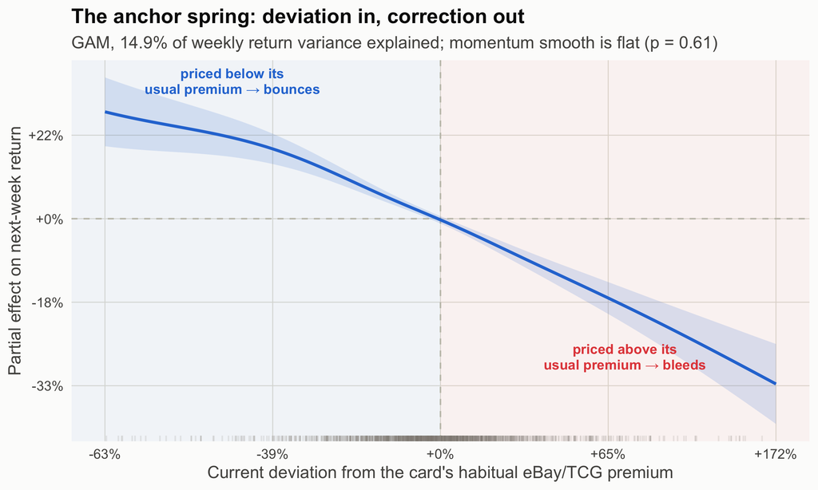

GAM partial effect of the anchor gap on next-week eBay return (95% CI). Cards below their habitual TCG-relative premium (left, blue zone) earn strong positive corrections; overpriced cards (right, red zone) bleed back — and the give-back runs steeper than the catch-up. Ticks on the baseline mark the observed gap distribution.

```r
grid_g <- data.frame(gap_dev = seq(-1, 1, .02), momentum = 0,
                     log_price = median(panel$log_price), card = panel$card[1])
pr <- predict(gm, grid_g, type = "terms", se.fit = TRUE, exclude = "s(card)")
curve <- tibble(gap_dev = grid_g$gap_dev,
                fit = pr$fit[, "s(gap_dev)"], se = pr$se.fit[, "s(gap_dev)"])

ggplot(curve, aes(gap_dev, fit)) +
  annotate("rect", xmin = -Inf, xmax = 0, ymin = -Inf, ymax = Inf,
           fill = tok$up, alpha = .05) +
  annotate("rect", xmin = 0, xmax = Inf, ymin = -Inf, ymax = Inf,
           fill = tok$down, alpha = .05) +
  geom_hline(yintercept = 0, colour = tok$baseline, linetype = "dashed") +
  geom_vline(xintercept = 0, colour = tok$baseline, linetype = "dashed") +
  geom_ribbon(aes(ymin = fit - 1.96 * se, ymax = fit + 1.96 * se),
              fill = tok$up, alpha = .15) +
  geom_line(colour = tok$up, linewidth = 1) +
  geom_rug(data = panel |> filter(abs(gap_dev) <= 1),
           aes(x = gap_dev), inherit.aes = FALSE,
           sides = "b", colour = tok$muted, alpha = .15, length = unit(4, "pt")) +
  annotate("text", x = -.62, y = .33, label = "priced below its\nusual premium → bounces",
           colour = tok$up, size = 3.4, fontface = "bold", lineheight = .95) +
  annotate("text", x = .55, y = -.33, label = "priced above its\nusual premium → bleeds",
           colour = tok$down, size = 3.4, fontface = "bold", lineheight = .95) +
  scale_x_continuous(labels = \(x) sprintf("%+.0f%%", 100 * (exp(x) - 1))) +
  scale_y_continuous(labels = \(y) sprintf("%+.0f%%", 100 * (exp(y) - 1))) +
  labs(x = "Current deviation from the card's habitual eBay/TCG premium",
       y = "Partial effect on next-week return",
       title = "The anchor spring: deviation in, correction out",
       subtitle = sprintf("GAM, %.1f%% of weekly return variance explained; momentum smooth is flat (p = %.2f)",
                          100 * dev_expl,
                          summary(gm)$s.table["s(momentum)", "p-value"])) +
  theme_lorecaster()
```

### 2.2 Out-of-sample: does the gap actually forecast?

```r
test_anchors <- tail(anchors, 3)
tr <- panel |> filter(!anchor %in% test_anchors)
te <- panel |> filter(anchor %in% test_anchors)
oos_r2 <- function(form) {
  m <- lm(form, data = tr)
  1 - sum((te$fwd_ret_w - predict(m, te))^2) / sum((te$fwd_ret_w - mean(tr$fwd_ret_w))^2)
}
r2_gap <- oos_r2(fwd_ret_w ~ gap_dev)
r2_mom <- oos_r2(fwd_ret_w ~ momentum)
r2_both <- oos_r2(fwd_ret_w ~ gap_dev + momentum)
```

Trained on the first 9 weeks and tested on the last 3, the gap alone delivers an out-of-sample R² of **18.0%** on next-week returns; momentum alone manages 8.0%, and adding it to the gap adds nothing (14.8%, slightly *worse* — the extra parameter is noise). An out-of-sample R² near 18% on *weekly* returns is unusually strong for a financial panel — a reminder that this is a thin collectibles market correcting mechanical mispricings, not an efficient exchange — and the signal is computable every morning from data the pipeline already collects.

## 3. Microstructure: what a price does to a listing’s lifespan

The scrape watches every listing appear and disappear — 16,928 fixed-price listings born inside the observation window. Disappearance mostly means sold, sometimes delisted; either way it is *inventory clearing*. A Cox proportional hazards model asks how a listing’s **entry price relative to its card’s same-condition market** changes its clearance rate.

```r
first_day <- min(px$date); last_day <- max(as.Date(daily_all$date_pulled))
ref <- daily_split |>
  transmute(id, date = as.Date(date_pulled), is_graded,
            ref_price = median_price, ref_n = n_active)

lc <- lifecycle |>
  mutate(first_seen = as.Date(first_seen), last_seen = as.Date(last_seen)) |>
  filter(first_seen > first_day,
         grepl("FIXED_PRICE", listing_type), !grepl("AUCTION", listing_type),
         entry_price > 0) |>
  inner_join(ref, by = c("id", "first_seen" = "date", "is_graded")) |>
  filter(ref_n >= 5) |>
  mutate(rel_price = entry_price / ref_price,
         log_rel = log(rel_price),
         duration = as.numeric(last_seen - first_seen) + 1,
         event = as.integer(last_seen < last_day - 1)) |>
  filter(rel_price > 0.1, rel_price < 10)

cx <- coxph(Surv(duration, event) ~ log_rel + is_graded, data = lc, cluster = id)
hr <- exp(coef(cx)); ci <- exp(confint(cx))
```

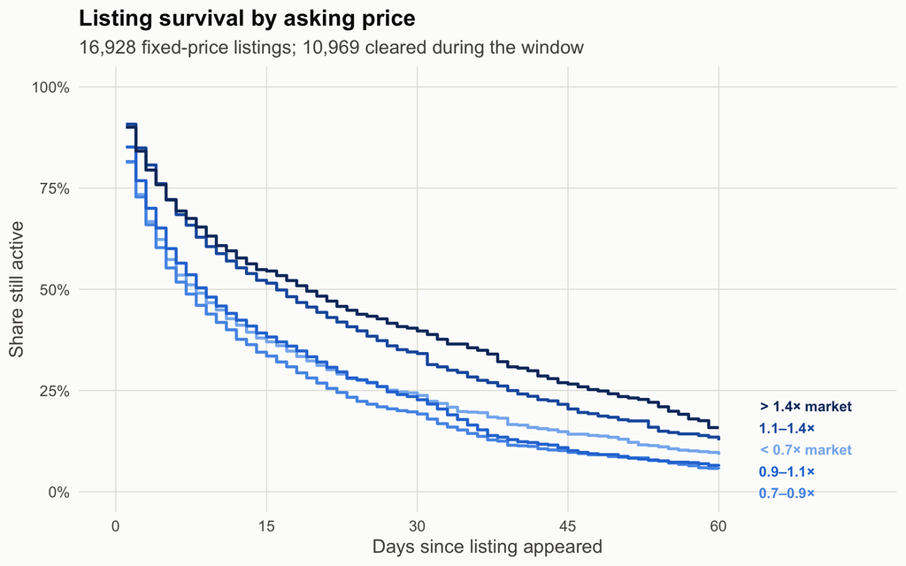

```r
lc <- lc |> mutate(band = cut(rel_price, c(0, .7, .9, 1.1, 1.4, Inf),
  labels = c("< 0.7× market", "0.7–0.9×", "0.9–1.1×", "1.1–1.4×", "> 1.4× market")))
sf <- survfit(Surv(duration, event) ~ band, data = lc)
km <- tidy(sf) |>
  mutate(band = factor(sub("band=", "", strata), levels = levels(lc$band)))

band_cols <- setNames(tok$seq5, levels(lc$band))
lab_km <- km |> filter(time <= 60) |> group_by(band) |> slice_max(time, n = 1)

ggplot(km |> filter(time <= 60), aes(time, estimate, colour = band)) +
  geom_step(linewidth = 0.9) +
  geom_text_repel(data = lab_km, aes(label = band), size = 3.2,
                  fontface = "bold", nudge_x = 4, direction = "y",
                  hjust = 0, segment.colour = NA, show.legend = FALSE) +
  scale_colour_manual(values = band_cols, name = "Entry price") +
  scale_y_continuous(labels = scales::percent, limits = c(0, 1)) +
  scale_x_continuous(limits = c(0, 74), breaks = seq(0, 60, 15)) +
  labs(x = "Days since listing appeared", y = "Share still active",
       title = "Listing survival by asking price",
       subtitle = sprintf("%s fixed-price listings; %s cleared during the window",
                          format(nrow(lc), big.mark = ","),
                          format(sum(lc$event), big.mark = ","))) +
  theme_lorecaster() +
  theme(legend.position = "none")
```

```r
med <- summary(sf)$table
tibble(Band = levels(lc$band),
       Listings = med[, "records"],
       `Median days to clear` = med[, "median"]) |>
  kable(caption = "Median listing lifetime by entry price band.")
```

Median listing lifetime by entry price band.

| Band | Listings | Median days to clear |
| --- | --- | --- |
| < 0.7× market | 2845 | 8 |
| 0.7–0.9× | 3589 | 7 |
| 0.9–1.1× | 4865 | 9 |
| 1.1–1.4× | 2259 | 16 |
| > 1.4× market | 3370 | 19 |

The hazard ratio on log relative price is **0.8** (95% CI 0.7– 0.91, card-clustered): pricing at double the market slows clearing by ~14%. Graded slabs clear 8% slower than raw copies (borderline, p = 0.055) — the graded market is where inventory *sits*, which is exactly why a graded-flooded book read as bearish in the softmax model.

## 4. Not one market — four

Card-level behavior over the window (price level, habitual premium, volatility, listing depth, graded share, TCG drift) clusters into four soft but readable segments (k chosen by silhouette).

```r
gr_share <- daily_split |>
  group_by(id) |>
  summarise(graded_share = 100 * sum(n_active * is_graded) / sum(n_active),
            .groups = "drop") |>
  inner_join(meta |> select(id, tcgplayer_id), by = "id")

card_stats <- px |>
  group_by(tcgplayer_id) |>
  arrange(date, .by_group = TRUE) |>
  summarise(n_days = n(), price_usd = median(tcg_price), premium = mean(gap),
            wk_vol = sd(diff(log(eb_price), lag = 7), na.rm = TRUE),
            liquidity = mean(n_active),
            tcg_drift = (last(log(tcg_price)) - first(log(tcg_price))) /
                        as.numeric(last(date) - first(date)) * 7,
            .groups = "drop") |>
  filter(n_days >= 60) |>
  inner_join(gr_share |> select(tcgplayer_id, graded_share), by = "tcgplayer_id") |>
  inner_join(meta |> distinct(tcgplayer_id, name, version), by = "tcgplayer_id")

X <- card_stats |>
  transmute(log_price = log(price_usd), premium, wk_vol,
            log_liq = log(liquidity), graded_share, tcg_drift) |> scale()
set.seed(99)
sil <- sapply(2:7, \(k) mean(silhouette(kmeans(X, k, nstart = 50)$cluster,
                                        dist(X))[, 3]))
k_best <- (2:7)[which.max(sil)]
km4 <- kmeans(X, k_best, nstart = 100)

card_stats$cluster <- factor(km4$cluster)

seg_summary <- card_stats |> group_by(cluster) |>
  summarise(n = n(), `Median TCG $` = round(median(price_usd)),
            `Ask premium` = sprintf("%.0f%%", 100 * (exp(mean(premium)) - 1)),
            `Weekly vol` = sprintf("%.0f%%", 100 * mean(wk_vol)),
            `Avg listings` = round(mean(liquidity)),
            `% graded` = round(mean(graded_share)),
            `TCG drift/wk` = sprintf("%+.1f%%", 100 * mean(tcg_drift)))
```

```r
# name clusters by profile, claiming the most distinctive trait first
prof <- card_stats |> group_by(cluster) |>
  summarise(price = median(price_usd), prem = mean(premium),
            vol = mean(wk_vol), liq = mean(liquidity), .groups = "drop")
lab <- prof |> mutate(seg = NA_character_)
lab$seg[which.max(lab$price)] <- "High-end heat"
lab$seg[is.na(lab$seg)][which.min(lab$price[is.na(lab$seg)])] <- "Lottery tickets"
lab$seg[is.na(lab$seg)][which.max(lab$liq[is.na(lab$seg)])] <- "Liquid slab walls"
lab$seg[is.na(lab$seg)] <- "Quiet staples"
lab <- lab |> select(cluster, seg)
card_stats <- card_stats |> left_join(lab, by = "cluster")
seg_summary |> left_join(lab, by = "cluster") |>
  relocate(Segment = seg) |> select(-cluster) |>
  kable(caption = sprintf(
    "k-means segments (k = %d by silhouette) over %d cards with ≥60 qualifying days.",
    k_best, nrow(card_stats)))
```

k-means segments (k = 4 by silhouette) over 160 cards with ≥60 qualifying days.

| Segment | n | Median TCG $ | Ask premium | Weekly vol | Avg listings | % graded | TCG drift/wk |
| --- | --- | --- | --- | --- | --- | --- | --- |
| Liquid slab walls | 58 | 45 | 148% | 18% | 26 | 46 | +3.6% |
| Quiet staples | 49 | 43 | 67% | 19% | 12 | 14 | +2.1% |
| Lottery tickets | 12 | 10 | 344% | 46% | 17 | 23 | +7.3% |
| High-end heat | 41 | 123 | 124% | 44% | 11 | 39 | +5.3% |

[figure not shown]

The Enchanted market’s four temperaments: habitual ask premium vs. weekly volatility, point size = listing depth. Labels mark the card nearest each segment centroid.

```r
seg_cols <- setNames(tok$cat4, sort(unique(card_stats$seg)))
exemplars <- card_stats |>
  group_by(cluster) |>
  mutate(d = mahalanobis(pick(premium, wk_vol),
                         c(mean(premium), mean(wk_vol)),
                         cov(cbind(premium, wk_vol)) + diag(2) * 1e-6)) |>
  slice_min(d, n = 1) |> ungroup()

ggplot(card_stats, aes(premium, 100 * wk_vol,
                       colour = seg, size = liquidity)) +
  geom_point(alpha = .65) +
  geom_point(data = exemplars, shape = 21, stroke = 1.1,
             fill = NA, colour = tok$ink, show.legend = FALSE) +
  geom_text_repel(data = exemplars,
                  aes(label = paste0(name, "\n", version)),
                  size = 3, colour = tok$ink2, fontface = "bold",
                  lineheight = .9, min.segment.length = 0, box.padding = .8,
                  show.legend = FALSE) +
  scale_colour_manual(values = seg_cols, name = NULL,
                      guide = guide_legend(override.aes = list(size = 3))) +
  scale_size_continuous(range = c(1.5, 7), guide = "none") +
  scale_x_continuous(breaks = log(1 + c(0, .5, 1, 3, 10, 20)),
                     labels = c("0%", "+50%", "+100%", "+300%",
                                "+1,000%", "+2,000%")) +
  scale_y_continuous(labels = \(y) sprintf("%.0f%%", y)) +
  labs(x = "Habitual eBay ask premium over TCGplayer",
       y = "Weekly price volatility (eBay median)",
       title = "Four temperaments of the Enchanted market") +
  theme_lorecaster()
```

Does the spring pull equally hard everywhere? Interacting the gap with segment membership:

```r
panel_seg <- panel |>
  inner_join(card_stats |> select(tcgplayer_id, seg), by = "tcgplayer_id")
m_int <- lm(fwd_ret_w ~ gap_dev * seg, data = panel_seg)
co <- summary(m_int)$coefficients
base_seg <- sort(unique(panel_seg$seg))[1]
slopes <- tibble(seg = sort(unique(panel_seg$seg))) |>
  mutate(slope = coef(m_int)["gap_dev"] +
           ifelse(seg == base_seg, 0,
                  coef(m_int)[paste0("gap_dev:seg", seg)] |> coalesce(0)))
kable(slopes |> mutate(slope = round(slope, 2),
                       `half-life (wk)` = round(log(.5) / log(1 + slope), 1)),
      caption = "Gap-correction slope by segment (more negative = faster correction).")
```

Gap-correction slope by segment (more negative = faster correction).

| seg | slope | half-life (wk) |
| --- | --- | --- |
| High-end heat | -0.43 | 1.2 |
| Liquid slab walls | -0.35 | 1.6 |
| Lottery tickets | -0.16 | 4.0 |
| Quiet staples | -0.32 | 1.8 |

Every segment corrects, but **lottery tickets correct slowest** — cheap, hype-driven cards can float above their anchor for a month or more. That is where “this time it’s different” stories live, and where the risk flag from the softmax report matters most.

## 5. So what? Today’s board

Everything above compresses into one number per card per day: **today’s deviation from its habitual anchor premium**, scored through the GAM. As of the last pull (2026-07-06):

```r
today <- max(px$date)
board <- px |> filter(date == today, n_active >= 5) |>
  inner_join(meta |> distinct(tcgplayer_id, name, version), by = "tcgplayer_id") |>
  filter(tcg_price >= 10)
board$pred <- predict(gm, board |>
    mutate(momentum = 0, log_price = log(eb_price),
           card = factor(panel$card[1], levels = levels(panel$card))),
  exclude = "s(card)")
board <- board |> arrange(gap_dev)

show_board <- bind_rows(head(board, 6) |> mutate(side = "Trading cheap vs. anchor"),
                        tail(board, 6) |> mutate(side = "Trading rich vs. anchor")) |>
  transmute(side, Card = ifelse(is.na(version) | version == "",
                                name, paste0(name, " — ", version)),
            `TCG $` = round(tcg_price, 0), `eBay median $` = round(eb_price, 0),
            `Deviation` = sprintf("%+.0f%%", 100 * (exp(gap_dev) - 1)),
            `Model 7-day outlook` = sprintf("%+.1f%%", 100 * (exp(pred) - 1)))
kable(show_board |> select(-side) |> as.data.frame(),
      caption = sprintf("Cards furthest from their habitual anchor premium on %s. Top 6: below anchor (model expects recovery). Bottom 6: above anchor (model expects give-back). Outlook is the GAM partial prediction — a tilt, not a promise.",
                        format(today)))
```

Cards furthest from their habitual anchor premium on 2026-07-06. Top 6: below anchor (model expects recovery). Bottom 6: above anchor (model expects give-back). Outlook is the GAM partial prediction — a tilt, not a promise.

| Card | TCG $ | eBay median $ | Deviation | Model 7-day outlook |
| --- | --- | --- | --- | --- |
| I2I | 508 | 1300 | -88% | +120.8% |
| Powerline — Musical Superstar | 13 | 16 | -67% | +32.5% |
| Be King Undisputed | 12 | 14 | -63% | +29.3% |
| Tigger — In the Crow’s Nest | 146 | 111 | -57% | +29.2% |
| Namaari — Morning Mist | 37 | 39 | -56% | +27.4% |
| Archimedes — Electrified Owl | 56 | 75 | -53% | +26.7% |
| The Islands I Pulled From the Sea | 55 | 120 | +79% | -17.6% |
| You’re Welcome | 88 | 250 | +79% | -17.1% |
| Chip ‘n’ Dale — Recovery Rangers | 80 | 421 | +80% | -16.7% |
| Merida — Formidable Archer | 1822 | 2767 | +82% | -15.3% |
| Into the Unknown | 263 | 894 | +91% | -18.0% |
| The Sword of Hercules | 42 | 120 | +98% | -21.0% |

**Caveats that keep this honest.** The response variable throughout is the *median active listing price* — an ask-side index, not a transaction price (though §3 shows transactions cluster near the anchor). “Cleared” conflates sold with delisted. The overlap window is one 103-day season; regime changes (set releases, reprints) can move the habitual premium itself. And 12 weekly anchors per card is thin — every headline number above ships with clustered uncertainty for exactly that reason.

## 6. What this changes

1. **Retire “momentum” as a concept for this market; adopt the anchor gap.** It subsumes momentum entirely, forecasts out-of-sample (R² ≈ 18% weekly), has a mechanical explanation (hopeful asks decaying toward the transaction anchor), and is computable daily from existing tables.
2. **The plan’s premise inverts**: eBay is not the leading indicator — TCGplayer is the anchor and eBay is the orbit. eBay’s value in the pipeline is *breadth* (composition, gradedness, depth, lifecycle), not price discovery.
3. **Listing depth is demand-side truth serum**: sub-anchor inventory clears in days. A card whose cheap listings *don’t* clear is genuinely cold — a sharper bearish flag than any price series.
4. **Segment before you model.** Correction speed differs by temperament; lottery tickets deserve wider bands and slower expected reversion in any daily monitor (“Step D” of the original plan).

**NoteReproducibility**

Card-day join: 20,102 rows (depth ≥ 5). Weekly Granger/ECM: 2,076 card-weeks. Showdown panel: 1,619 card-weeks, 12 anchors. Survival: 16,928 fixed-price listings born after 2026-03-25. Segmentation: 160 cards, k = 4. Seeds: 1789 (session), 7 (ECM bootstrap), 99 (k-means). Render: `quarto render exploration/softmax_report/market_anatomy.qmd`.